# Grafico y desarrollo

Como mencione en la introduccion, el proposito de este informe es analizar que tipo de impacto generan los espectadores en la copa mundial de futbol. Para lo cual recopile informacion desde el primer mundial hasta el ultimo sobre los goles y la asistencia que cada uno tuvo.

Para saber si sera posible explicar los goles realizados por mundial en funcion de los espectadores que tuvo el mundial, visualizaremos un grafico de dispersion entre estas variables.

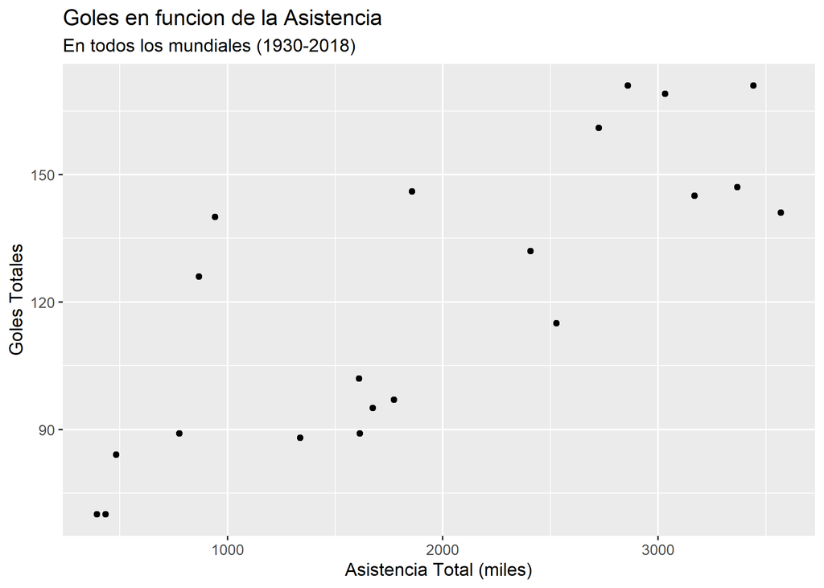

Como podemos notar existe una tendencia creciente entre los goles realizados por mundial y los espectadores que tuvo el mundial, por lo que es probable que estas dos variables tengan una correlacion positiva.

Verificaremos su correlacion.

```r
cor(AsisTotal,goles)
```

```
## [1] 0.7940947
```

Como podemos ver la correlacion entre los goles realizados por mundial y los espectadores que tuvo el mundial es positva y ademas alta, por lo que sera posible generar una recta de regresion que me permita explicar los goles realizados en un mundial a traves de la asistencia total de dicho mundial.

```r
regresion = lm(goles ~ AsisTotal)
summary(regresion)
```

```
##
## Call:
## lm(formula = goles ~ AsisTotal)
##
## Residuals:
##     Min      1Q  Median      3Q     Max
## -23.943 -17.906  -7.308  19.929  44.079
##
## Coefficients:
##              Estimate Std. Error t value Pr(>|t|)
## (Intercept) 7.202e+01  9.814e+00   7.339 5.89e-07 ***
## AsisTotal   2.534e-05  4.450e-06   5.695 1.73e-05 ***
## ---
## Signif. codes:  0 '***' 0.001 '**' 0.01 '*' 0.05 '.' 0.1 ' ' 1
##
## Residual standard error: 21.17 on 19 degrees of freedom
## Multiple R-squared:  0.6306, Adjusted R-squared:  0.6111
## F-statistic: 32.43 on 1 and 19 DF,  p-value: 1.726e-05
```

Podemos ver que tanto el intercepto como la recta de regresion son significativos para este modelo, por ende, existe una recta que sera capaz de explicar los goles en funcion de la asistencia (de cada mundial).

Visualizaremos el grafico de dispersion junto con la recta de la regresion.

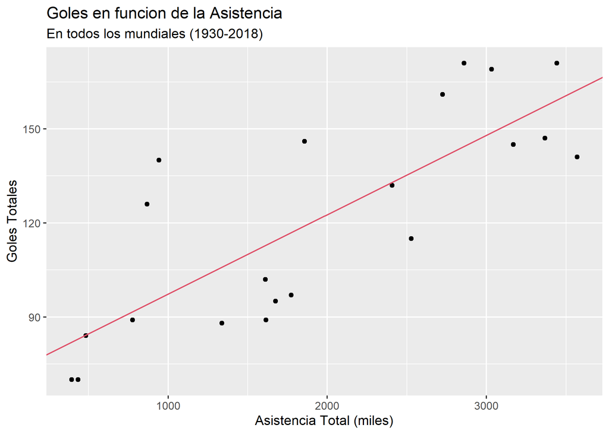